# Impacto del proceso de vacunación contra el Covid-19

Grupo 3  
11 de Junio de 2021

### Importancia

El estudio busca sensibilizar e informar a la población sobre los efectos generados por el proceso de vacunación contra la Covid-19 en las regiones del Perú, por lo que se considera un tema de interés público debido al contexto actual.

### Obtención de los datos

Plataforma Nacional de Datos Abiertos

- [Datos sobre vacunados](https://www.datosabiertos.gob.pe/dataset/vacunaci%C3%B3n-contra-covid-19-ministerio-de-salud-minsa-0):
  - Datos faltantes: 127931 –> 0
  - Observaciones completas: 2671786 –> 4571604
  - Porcentaje de observaciones incompletas: 4.57 –> 0
- [Datos sobre fallecidos](https://www.datosabiertos.gob.pe/dataset/fallecidos-por-covid-19-ministerio-de-salud-minsa/resource/4b7636f3-5f0c-4404-8526):
  - Datos faltantes: 0 -> 1
  - Observaciones completas: 66770 –> 187157
- Data tomada hasta el 8 de junio del 2021

## Figuras de merito

### DataSet: Fallecidos

¿Cómo influye la llegada de las vacunas en la cantidad de fallecidos por COVID?

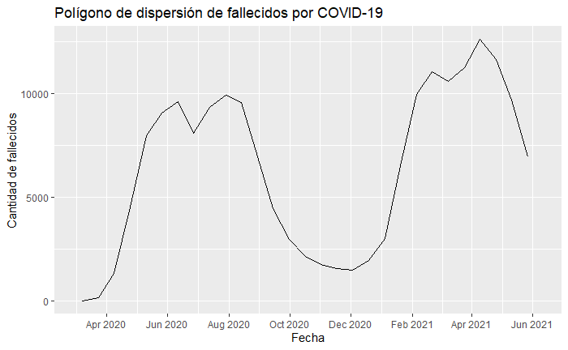

El pico más alto de la cantidad de fallecidos fue obtenido durante este periodo.

La máxima cantidad de fallecidos en un dia es 845.

La mínima cantidad de fallecidos en un dia es 1.

### DataSet: Fallecidos

¿Será cierto que los adultos mayores son las personas que más fallecieron por COVID?

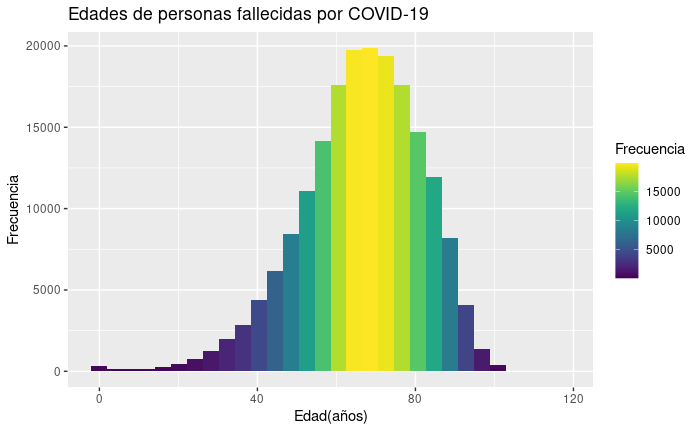

Las personas que más fallecieron tenían entre 60 y 80 años.

La edad mínima de los fallecidos es 0.

La edad máxima de los fallecidos es 117.

### DataSet: Fallecidos

¿Existe alguna diferencia entre la cantidad de fallecidos y su género?

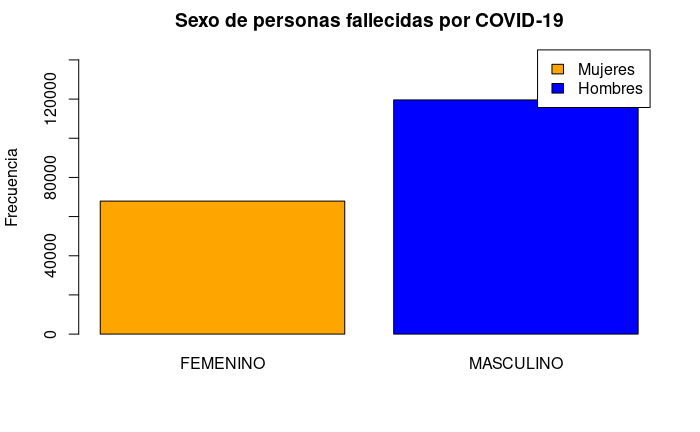

En el Perú, la gran mayoría de personas fallecidas por COVID son hombres.

### DataSet: Fallecidos

¿Es cierto que los departamentos del Norte tienen la mayor cantidad de fallecidos por COVID?

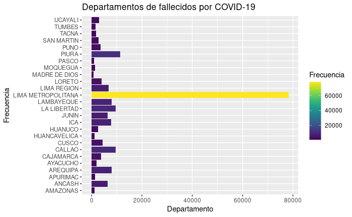

Lima es el departamento con mayor cantidad de fallecidos por COVID

### DataSet: Proceso de Vacunacion

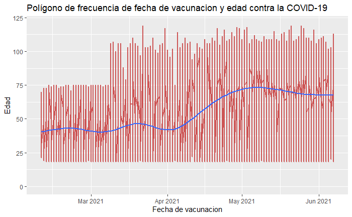

La mayor cantidad de vacunados en un día es 153066.

La menor cantidad de vacunados en un día es 86.

### DataSet: Proceso de Vacunacion

¿Es cierto que el género de la mayor cantidad de personas vacunadas es el mismo que de las personas fallecidas?

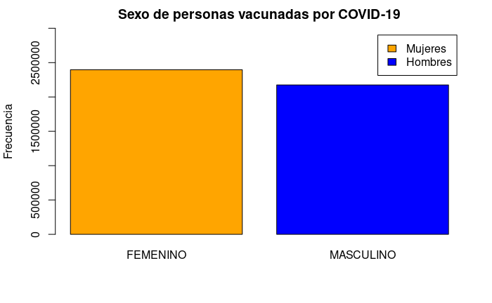

La mayor cantidad de personas vacunadas son mujeres.

### DataSet: Proceso de Vacunacion

¿Existe la misma cantidad de dosis aplicadas en las personas vacunadas del Perú?

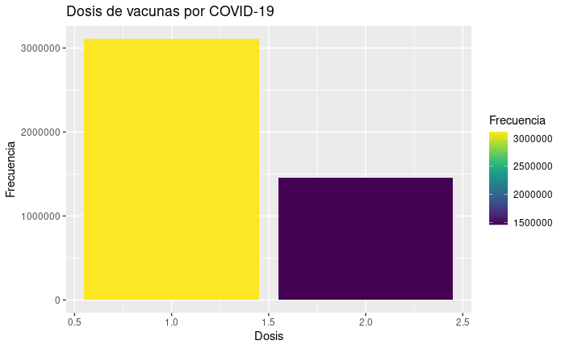

La mayor cantidad de dosis aplicadas es la primera.

### DataSet: Proceso de Vacunacion

¿Será el mayor fabricante de vacunas del mundo (AstraZeneca) el que distribuye mayor cantidad de vacunas al Perú?

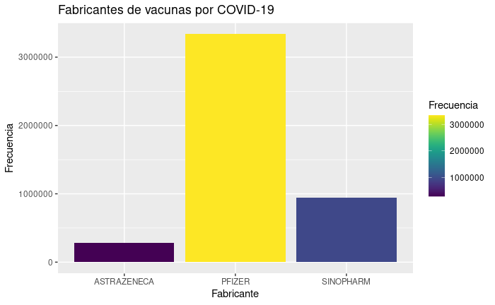

El fabricante que más cantidad de vacunas distribuye al Perú es Pfizer.

El fabricante que menos cantidad de vacunas distribuye al Perú es Astrazeneca.

### DataSet: Proceso de Vacunacion

¿Es cierto que el departamento con la mayor cantidad de personas vacunadas es el mismo que de las personas fallecidas?

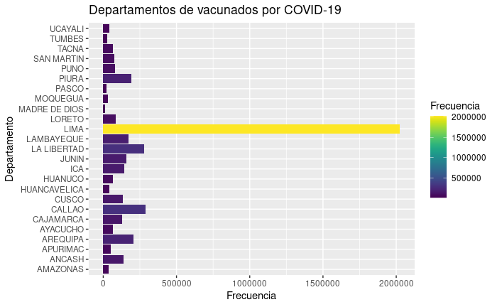

El departamento con mayor cantidad de personas vacunadas es Lima.

## Patrones

### Patrones

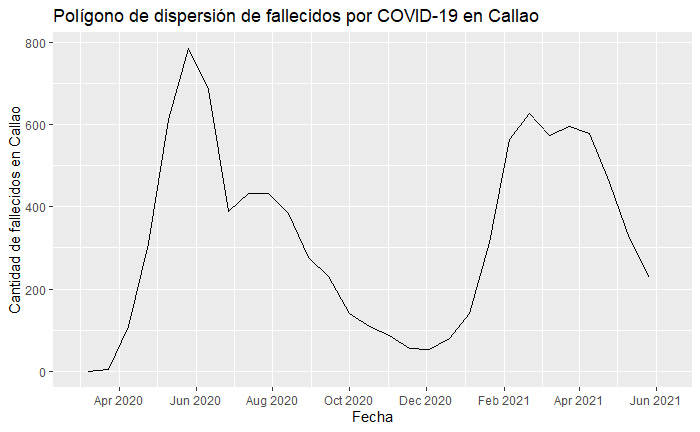

### Patrones

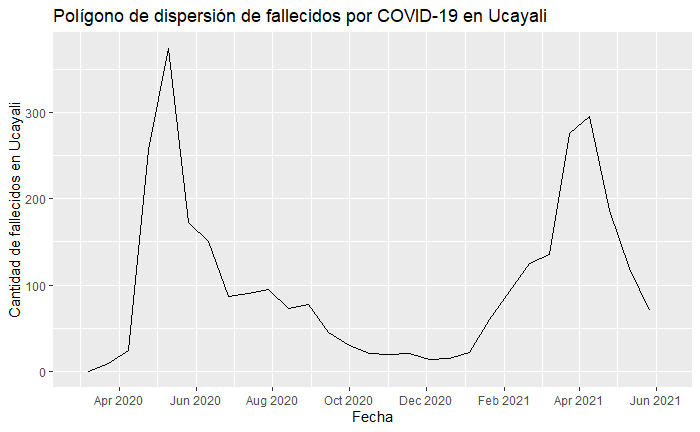

### Patrones

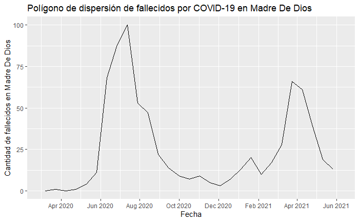

## Modelos de Variable Aleatoria

### Modelos de Variable Aleatoria

Que tan probable es que eligiendo una persona al azar de nuestra muestra, esta sea un adulto mayor de Lima y haya sido vacunado con el fabricante Pfizer. (No es equiprobable)

0.27

Qué tan probable es que en UCAYALI exista un adulto mayor con 2 dosis y de género masculino

Menor a 0.01

Qué tan probable es que eligiendo una persona al azar esta sea una mujer y tenga 1 dosis

0.36

### Modelos de Variable Aleatoria

Qué tan probable es que el fabricante de una vacuna aplicada sea Sinopharm

0.21

Qué tan probable es que el género de una persona fallecida sea hombre

0.64

Qué tan probable es que la etapa de vida de una persona fallecida sea adulto mayor(60 a más)

0.7

## Relaciones

### Relaciones

Cantidad de fallecidos en la 2da ola por etapa de vida x Cantidad de vacunados en la 2da ola por etapa de vida

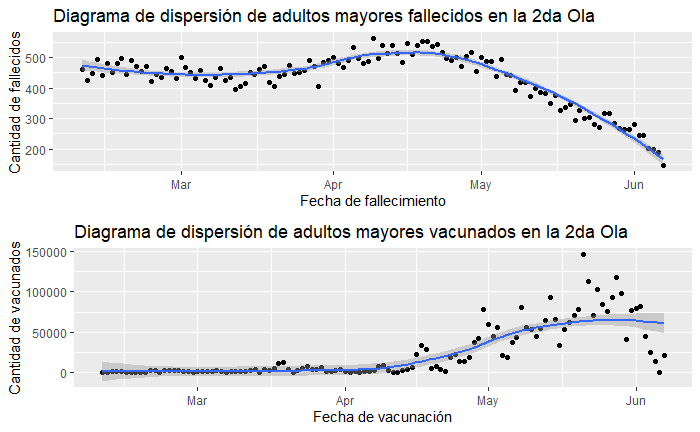

Adultos Mayores - Correlación: -0.5704937

### Relaciones

Cantidad de fallecidos en la 2da ola por etapa de vida x Cantidad de vacunados en la 2da ola por etapa de vida

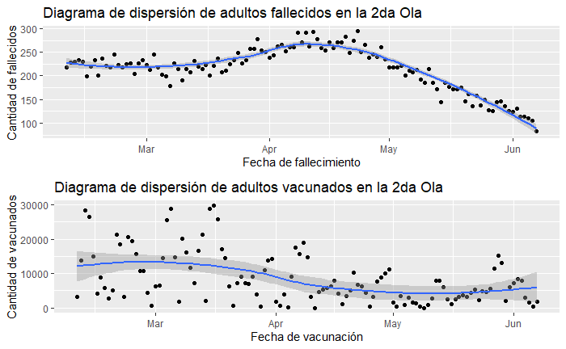

Adultos - Correlación: 0.1306875

### Relaciones

Cantidad de fallecidos en la 2da ola por etapa de vida x Cantidad de vacunados en la 2da ola por etapa de vida

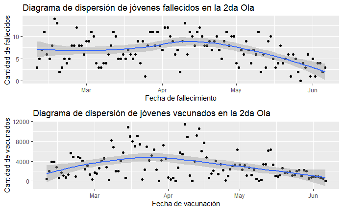

Jóvenes - Correlación: 0.04970341

### Relaciones

Cantidad de fallecidos por departamento en la 2da ola x Cantidad de vacunados por departamento en la 2da ola en el departamento con más vacunados

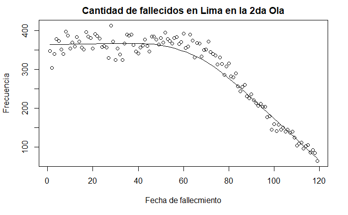

Lima, es la ciudad con más fallecidos - Correlación: -0.4668205

### Relaciones

Cantidad de vacunados por departamento en la 2da ola x Cantidad de vacunados por departamento en la 2da ola en el departamento con más vacunados

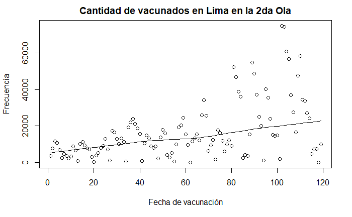

Lima, es la ciudad con más vacunados - Correlación: -0.4668205<

### Relaciones

Cantidad de fallecidos por departamento en la 2da ola x Cantidad de vacunados por departamento en la 2da ola en el departamento con menos vacunados

[figure not shown]

Madre de Dios, es la ciudad con menos vacunados - Correlaccón: -0.1124028

### Relaciones

Cantidad de vacunados por departamento en la 2da ola x Cantidad de vacunados por departamento en la 2da ola en el departamento con menos vacunados

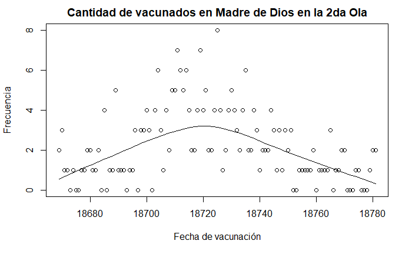

Madre de Dios, es la ciudad con menos vacunados - Correlaccón: -0.1124028

## Gracias

¿Preguntas?